# Lesson 2 : LangGraph Components

### Overview

[figure not shown]

### example tools on langchain hub

[figure not shown]

```python
from dotenv import load_dotenv
_ = load_dotenv() # Load OpenAI API key
```

```python
from langgraph.graph import StateGraph, END
from typing import TypedDict, Annotated # Used to constructe Anget state

import operator
from langchain_core.messages import AnyMessage, SystemMessage, HumanMessage, ToolMessage

# LangChain wrapper to OpenAI, but can be any other LLM provide that LangChain support without chaning other code
from langchain_openai import ChatOpenAI
from langchain_community.tools.tavily_search import TavilySearchResults
```

```python
#increased number of results, maximum 4 responds from the search API
tool = TavilySearchResults(max_results=4)
print(type(tool))

# tavily_search_results_json is the name that language model will use too call this tool
print(tool.name)
```

```
<class 'langchain_community.tools.tavily_search.tool.TavilySearchResults'>
tavily_search_results_json
```

> If you are not familiar with python typing annotation, you can refer to the [python documents](https://docs.python.org/3/library/typing.html).

## State in LangGraph

One of the most important things to understand when working with LangGraph is the state that is tracked over time. This is often called the agent state. This is accessible at all parts of the graph at each node in each edge. It is local to the graph and it can be stored in persistence layer, meaning that you can resume with that state at any point in time, later on.

```python
# Sai:
# The message variable is a sequence of base message. Base Message is a LangChain type.
# It's annotated with operator.add.
# This means that when the state is updated with new messages,
# it doesn't override the existing messages, but rather it adds them to that state.

class AgentState(TypedDict):
    messages: Annotated[list[AnyMessage], operator.add]
```

> Note: in `take_action` below, some logic was added to cover the case that the LLM returned a non-existent tool name. Even with function calling, LLMs can still occasionally hallucinate. Note that all that is done is instructing the LLM to try again! An advantage of an agentic organization.

[figure not shown]

We can see that we will have one node. We'll call this call OpenAl. And this will call the LLM. We'll then have a conditional edge which will check for the existence of an action to take. And so we'll call this 'exists action'. And then we'll have another node which actually executes that action. We'll call that 'take action'. And the state that will track is pretty simple. It's just this list of messages to which we add over time.

```python
# we're going to need three functions.
# - call_openai() to call OpenAl
# - take_action() to check whether there is an action present
# - exists_action() to take that action.

# 2 as nodes, 1 as edges
class Agent:

    def __init__(self, model, tools, system=""):
        self.system = system
        graph = StateGraph(AgentState)

        graph.add_node("llm", self.call_openai)
        graph.add_node("action", self.take_action)
        graph.add_conditional_edges(
            "llm",
            self.exists_action,
            # A dictionary to represent how the map to repsonse of the fucntion to the next node to go to
            # True -> take action. False -> END node
            {True: "action", False: END}
        )
        graph.add_edge("action", "llm") # Starting point(action) -> End point(LLM)
        graph.set_entry_point("llm")

        # Turn the setup to LangChain runnable
        # A LangChain runnable exposes a standard interface for calling and invoking this graph.
        self.graph = graph.compile()

        self.tools = {t.name: t for t in tools}
        self.model = model.bind_tools(tools) # Leting the model know we have these tools

    def call_openai(self, state: AgentState):
        messages = state['messages']
        if self.system:
            messages = [SystemMessage(content=self.system)] + messages
        message = self.model.invoke(messages)

        # [Important] It isn't overwrite the state, but add the message to the state!
        return {'messages': [message]}

    def take_action(self, state: AgentState):
        tool_calls = state['messages'][-1].tool_calls # Get the last message for calling the tools
        results = []

        # A lot of the more modern models support parallel tool or parallel function calling.
        # What we can now do is we can loop over these tool calls.
        # We can find the relevant tool by looking up tool name in the dictionary of tools that we created.
        for t in tool_calls:
            print(f"Calling: {t}")
            if not t['name'] in self.tools:      # check for bad tool name from LLM
                print("\n ....bad tool name....")
                result = "bad tool name, retry"  # instruct LLM to retry if bad
            else:
                result = self.tools[t['name']].invoke(t['args']) # Call the tools
            # Append the result
            results.append(ToolMessage(tool_call_id=t['id'], name=t['name'], content=str(result)))

        print("Back to the model!")

        # Agent will append the new message to the state
        return {'messages': results}

    # For checking if the action exsist
    def exists_action(self, state: AgentState):
        result = state['messages'][-1]
        return len(result.tool_calls) > 0
```

```python
prompt = """You are a smart research assistant. Use the search engine to look up information. \
You are allowed to make multiple calls (either together or in sequence). \
Only look up information when you are sure of what you want. \
If you need to look up some information before asking a follow up question, you are allowed to do that!
"""

model = ChatOpenAI(model="gpt-3.5-turbo")  #reduce inference cost
abot = Agent(model, [tool], system=prompt)
```

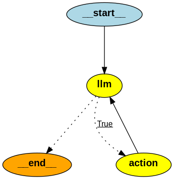

```python
from IPython.display import Image

Image(abot.graph.get_graph().draw_png())
```

## Call the angent

```python
# We have to do this because the state that the agent expects to work with has this messages attribute, which is a list of messages.
# So we need to make it conform with that state.
messages = [HumanMessage(content="What is the weather in sf?")] # HumanMessage is a user message
result = abot.graph.invoke({"messages": messages})
```

```
Calling: {'name': 'tavily_search_results_json', 'args': {'query': 'weather in San Francisco'}, 'id': 'call_f6SHV4z2VnHCaxMPV1GcNba8'}
Back to the model!
```

```python
result # the final state of the agent ended up in
```

```
{'messages': [HumanMessage(content='What is the weather in sf?'),
  AIMessage(content='', additional_kwargs={'tool_calls': [{'id': 'call_f6SHV4z2VnHCaxMPV1GcNba8', 'function': {'arguments': '{"query":"weather in San Francisco"}', 'name': 'tavily_search_results_json'}, 'type': 'function'}]}, response_metadata={'token_usage': {'completion_tokens': 21, 'prompt_tokens…
  ToolMessage(content='[{\'url\': \'https://www.weatherapi.com/\', \'content\': "{\'location\': {\'name\': \'San Francisco\', \'region\': \'California\', \'country\': \'United States of America\', \'lat\': 37.78, \'lon\': -122.42, \'tz_id\': \'America/Los_Angeles\', \'localtime_epoch\': 1725455768, …
  AIMessage(content='The current weather in San Francisco is partly cloudy with a temperature of 55.9°F (13.3°C). The wind speed is 13.0 kph coming from the West Northwest direction. The humidity is at 97%, and the visibility is 9.0 miles.', response_metadata={'token_usage': {'completion_tokens': 59…
```

```python
result['messages'][-1].content # The last message
```

```
'The current weather in San Francisco is partly cloudy with a temperature of 55.9°F (13.3°C). The wind speed is 13.0 kph coming from the West Northwest direction. The humidity is at 97%, and the visibility is 9.0 miles.'
```

```python
messages = [HumanMessage(content="What is the weather in SF and LA?")]
result = abot.graph.invoke({"messages": messages}) # parallel function or tool calling

# it will then have all the message the model needs to return the final message
```

```
Calling: {'name': 'tavily_search_results_json', 'args': {'query': 'current weather in San Francisco'}, 'id': 'call_pXFFL55gg7TYLo1IbBB2i75P'}
Calling: {'name': 'tavily_search_results_json', 'args': {'query': 'current weather in Los Angeles'}, 'id': 'call_U9B95qoy0OkVN4ERar5nwtDU'}
Back to the model!
```

```python
result['messages'][-1].content
```

```
'The current weather in San Francisco is partly cloudy with a temperature of 55.9°F. The wind speed is 13.0 kph coming from the west-northwest direction. The humidity is at 97%.\n\nIn Los Angeles, the weather is overcast with a temperature of 75.3°F. The wind speed is 3.6 kph blowing from the north.…
```

## Complex example

```python
# Note, the query was modified to produce more consistent results.
# Results may vary per run and over time as search information and models change.

query = "Who won the super bowl in 2024? In what state is the winning team headquarters located? \
What is the GDP of that state? Answer each question."
messages = [HumanMessage(content=query)]

model = ChatOpenAI(model="gpt-4o")  # requires more advanced model
abot = Agent(model, [tool], system=prompt)
result = abot.graph.invoke({"messages": messages})
```

```
Calling: {'name': 'tavily_search_results_json', 'args': {'query': 'Super Bowl 2024 winner'}, 'id': 'call_GQnvVhmohQsebbf4Dz8M7oz2'}
Back to the model!
Calling: {'name': 'tavily_search_results_json', 'args': {'query': 'Kansas City Chiefs headquarters location'}, 'id': 'call_s7MaNHcZYOxxZrBT9fqlA5O1'}
Back to the model!
Calling: {'name': 'tavily_search_results_json', 'args': {'query': 'GDP of Missouri 2024'}, 'id': 'call_ZknUVNhwImQJdjqGf8U2pj8L'}
Back to the model!
```

```python
print(result['messages'][-1].content) # Final respond
```

```
1. **Who won the Super Bowl in 2024?**
   - The Kansas City Chiefs won the Super Bowl in 2024, defeating the San Francisco 49ers 25-22 in overtime.

2. **In what state is the winning team's headquarters located?**
   - The Kansas City Chiefs' headquarters is located in Kansas City, Missouri.

3. **What is the GDP of that state?**
   - In 2023, the real gross domestic product (GDP) of Missouri was approximately $344.12 billion USD. The data for 2024 is not yet fully available, but it is likely to be in the same range or slightly higher given historical trends.
```

So the difference here is that in order to make the second query, it actually had to know the result of the first query.

So it calls one tool, then goes back to the model in order to enable it to call the second tool. This is a little bit different from **parallel function calling**. And the reason it's happening **sequentially**, is it actually needs the result of the first query, in order to make the second query at all.

With this, we've seen how we can take that raw LLM and raw Python example with some fake tools and turn it into a real agent that can answer complex questions.